```python
# ! conda install -c conda-forge -y pymc3==3.7
# ! conda install -y pytorch
# ! conda install -y seaborn
# ! conda install -y pandas
# ! conda install -y scikit-learn
```

```python
import re
import os
import string
import random
import pymc3 as pm
import numpy as np
import pandas as pd

import torch
import torch.nn as nn
import torch.optim as optimi
import torch.nn.functional as F

import torchvision
from torchvision import datasets, transforms
from torch.utils.data import DataLoader

import pyro
from pyro.optim import Adam
from pyro.infer import SVI, Trace_ELBO, Predictive
from pyro.distributions import Normal, Categorical

# import theano.tensor as T

import seaborn as sns
import matplotlib.pyplot as plt
from IPython.display import display

from sklearn.preprocessing import StandardScaler
from sklearn.model_selection import train_test_split
from sklearn.metrics import accuracy_score
from sklearn.datasets import make_moons, load_iris, load_wine
from scipy.special import softmax

import warnings
warnings.filterwarnings("ignore")

print(f"Running on PyMC3 v{pm.__version__}")
```

```
Running on PyMC3 v3.7
```

# Seeding everything first

- This will allow us to have reproducible experiments
- Unfortunately, the experiments in Pytorch are not

```python
seed = 43
random.seed(seed)
os.environ['PYTHONHASHSEED'] = str(seed)
np.random.seed(seed)
torch.manual_seed(seed)
torch.cuda.manual_seed(seed)
torch.backends.cudnn.deterministic = True
```

# Torch Pipeline for both binary and multiclass classification

- This will help us to compare models without rewriting the whole structure

```python
class TorchPipeline:
    def __init__(self, X_train, y_train, X_valid, y_valid, n_hidden, n_output, typs = 'binary', epochs = 500, lr = 0.01):
        assert typs in ['binary', 'multiclass']
        self.typs = typs

        epochs = epochs
        device = torch.device("cuda" if torch.cuda.is_available() else "cpu")
        model = self.ClassicNeuralNetwork(n_input = X_train.shape[1], n_hidden = n_hidden, n_output = n_output).to(device)

        criterion = None
        if self.typs == 'binary':
            criterion = nn.BCEWithLogitsLoss()
        else:
            criterion = nn.CrossEntropyLoss()

        optimizer = optimi.Adam(model.parameters(), lr = lr)

        X_train, X_valid = torch.tensor(X_train).to(device), torch.tensor(X_valid).to(device)
        y_train, y_valid = torch.tensor(y_train).to(device), torch.tensor(y_valid).to(device)

        train_losses, train_accuracies, valid_losses, valid_accuracies = [], [], [], []

        for epoch in range(epochs):
            train_loss, train_accuracy, model = self.train_epoch(model, X_train, y_train, optimizer, criterion)
            valid_loss, valid_accuracy, = self.valid_epoch(model, X_valid, y_valid, criterion)

            if epoch % 50 == 0:
                print("Epoch: {}, Train Loss: {}, Valid Loss: {}, Train Accuracy {}, Valid Accuracy: {}".format(epoch, train_loss, valid_loss, train_accuracy, valid_accuracy))

            train_losses.append(train_loss)
            train_accuracies.append(train_accuracy)

            valid_losses.append(valid_loss)
            valid_accuracies.append(valid_accuracy)

        fig, axs = plt.subplots(2, 2, figsize = (15, 8))
        axs[0, 0].plot(train_losses, label = "Train Losses")
        axs[0, 0].set_title("Train Losses")

        axs[0, 1].plot(valid_losses, label = "Valid Losses")
        axs[0, 1].set_title("Valid Losses")

        axs[1, 0].plot(train_accuracies, label = "Train Accuracies")
        axs[1, 0].set_title("Train Accuracies")

        axs[1, 1].plot(valid_accuracies, label = "Valid Accuracies")
        axs[1, 1].set_title("Valid Accuracies")

        plt.show()

    class ClassicNeuralNetwork(nn.Module):
        def __init__(self, n_input, n_hidden, n_output):
            super().__init__()

            self.n_input  = n_input
            self.n_hidden = n_hidden
            self.n_output = n_output

            self.fc1 = nn.Linear(n_input, n_hidden, bias = False)
            self.fc2 = nn.Linear(n_hidden, n_output, bias = False)

            self.activation = nn.Tanh()

            self.sigmoid = nn.Sigmoid()
            self.softmax = nn.Softmax()

        def forward(self, x):

            x = self.activation(self.fc1(x))
            x = self.fc2(x)

            return x

    def train_epoch(self, model, X_train, y_train, optimizer, criterion):
        model.train()
        optimizer.zero_grad()

        output = model(X_train.float()).squeeze(1)

        preds = None
        if self.typs == 'binary':
            y_train = y_train.float()

            probas = torch.sigmoid(output)
            preds  = torch.round(probas)
        else:
            y_train = F.one_hot(y_train)
            y_train = torch.max(y_train, 1)[1]

            probas  = F.softmax(output)
            preds   = torch.round(probas)
            preds   = torch.argmax(preds, dim = 1)

        loss = criterion(output, y_train)

        loss.backward()
        optimizer.step()

        preds  = preds.cpu().detach().numpy()
        labels = y_train.cpu().detach().numpy()

        accuracy   = accuracy_score(labels, preds)
        train_loss = loss.item()

        return np.round(train_loss, 3), np.round(accuracy, 3), model

    def valid_epoch(self, model, X_valid, y_valid, criterion):
        model.eval()

        with torch.no_grad():
            output = model(X_valid.float()).squeeze(1)

            preds = None
            if self.typs == 'binary':
                y_valid = y_valid.float()
                probas = torch.sigmoid(output)
                preds  = torch.round(probas)
            else:
                y_valid = F.one_hot(y_valid)
                y_valid = torch.max(y_valid, 1)[1]

                probas  = F.softmax(output)
                preds   = torch.round(probas)
                preds   = torch.argmax(preds, dim = 1)

            loss   = criterion(output, y_valid)

            preds  = preds.cpu().detach().numpy()
            labels = y_valid.cpu().detach().numpy()

            accuracy   = accuracy_score(labels, preds)
            valid_loss = loss.item()

        return np.round(valid_loss, 3), np.round(accuracy, 3)
```

# Utility functions to display datasets and posteriors

```python
def display_toy_dataset(X, Y, necessary = False):
    fig, ax = plt.subplots(figsize = (15, 7))
    ax.scatter(X[Y == 0, 0], X[Y == 0, 1], label="Class 0")
    ax.scatter(X[Y == 1, 0], X[Y == 1, 1], color="r", label="Class 1")

    if necessary:
        ax.scatter(X[Y == 2, 0], X[Y == 2, 1], color='y', label='Class 2')

    sns.despine()
    ax.legend()
    ax.set(xlabel="X", ylabel="Y", title="Toy binary classification data set");
```

```python
def display_posterior_weights(ppc):
    fig, axes = plt.subplots(2, 2, figsize = (17, 12))

    for neuron in range(ppc['w_1'].shape[1]):
        for layer in range(ppc['w_1'].shape[1]):
            posterior_weight = [ppc['w_1'][iteration][neuron][layer] for iteration in range(ppc['w_1'].shape[0])]
            axes[neuron, layer].hist(posterior_weight)
            axes[neuron, layer].set_title("Posteriori of w{}{}".format(neuron + 1, layer + 1))

    plt.show()

    fig, axes = plt.subplots(1, 2, figsize = (17, 6))
    for neuron in range(ppc['w_2'].shape[1]):
        posterior_weight = [ppc['w_2'][iteration][neuron] for iteration in range(ppc['w_2'].shape[0])]
        axes[neuron].hist(posterior_weight)
        axes[neuron].set_title("Posteriori of w{}{}".format(3, neuron + 1))

    plt.show()
```

# Sanity Check Dataset

- Just as a prove of concept
- With the same architecture as in the project description powerpoint

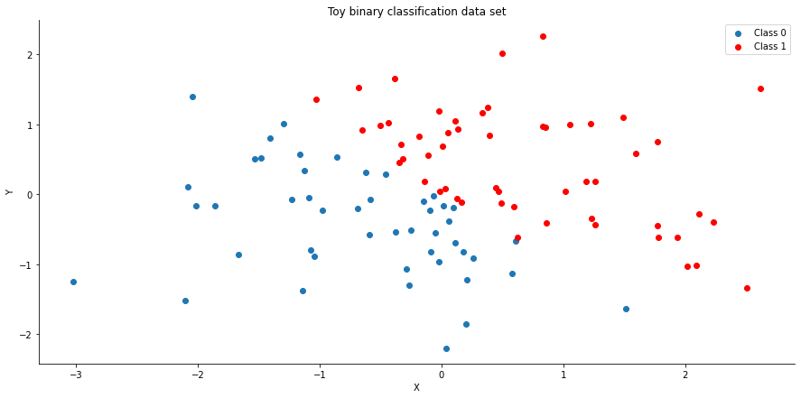

```python
X = np.random.randn(100, 2).astype(float)
Y = np.tanh(X[:, 0] + X[:, 1])
Y = 1. / (1. + np.exp(-(Y + Y)))
Y = Y > 0.5

display_toy_dataset(X, Y)
```

```python
X_train, X_valid, y_train, y_valid = train_test_split(X, Y, test_size = 0.2, random_state = seed, stratify = Y)

scaler = StandardScaler()
scaler.fit(X_train)

X_train = scaler.transform(X_train)
X_valid = scaler.transform(X_valid)
```

# Defining the Architecture and priors for weights

- A good source for Bayesian Networks is the Pymc documentation: https://docs.pymc.io/notebooks/bayesian_neural_network_advi.html

```python
def BinaryPymcNetwork(input_data, output_data, n_hidden):
    init_1 = np.random.randn(input_data.shape[1], n_hidden).astype(float)
    init_2 = np.random.randn(n_hidden).astype(float)

    total_size = output_data.shape[0]

    with pm.Model() as nn:
        input_data  = pm.Data('input_data',  input_data)
        output_data = pm.Data('output_data', output_data)

        # Generating the weights based on prior init variables
        weights_1 = pm.Normal("w_1", mu = 0, sigma = 1, shape = (X.shape[1], n_hidden), testval = init_1)
        weights_2 = pm.Normal("w_2", mu = 0, sigma = 1, shape = (n_hidden,), testval = init_2)

        activation_1 = pm.math.tanh(pm.math.dot(input_data, weights_1))
        activation_2 = pm.math.sigmoid(pm.math.dot(activation_1, weights_2))

        output = pm.Bernoulli("out", activation_2, observed = output_data, total_size = total_size)

    return nn
```

```python
model = BinaryPymcNetwork(X_train, y_train, n_hidden = 2)
```

```python
with model:
    approx = pm.fit(n = 30000)

trace = approx.sample(draws = 5000)
```

[output not shown]

# The main idea here is generating predictions based on posterior

- For that will use "sample_posterior_predictive" over the variables we are interested in, based on the trained model

# Results on the train set

```python
pm.set_data(new_data = {"input_data": X_train, "output_data": y_train}, model = model)

ppc = pm.sample_posterior_predictive(trace, samples = 500, progressbar = True, model = model, var_names = ['w_1', 'w_2', 'out'])

y_pred = ppc["out"].mean(axis = 0) > 0.5

print("Train Accuracy: {}".format(accuracy_score(y_train, y_pred)))
```

```
Train Accuracy: 0.9875
```

# Checking the posterior weights

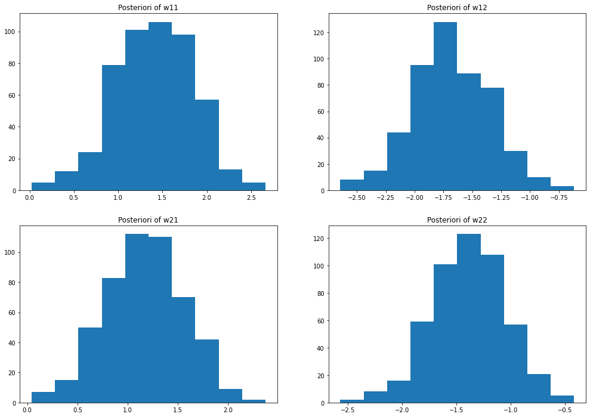

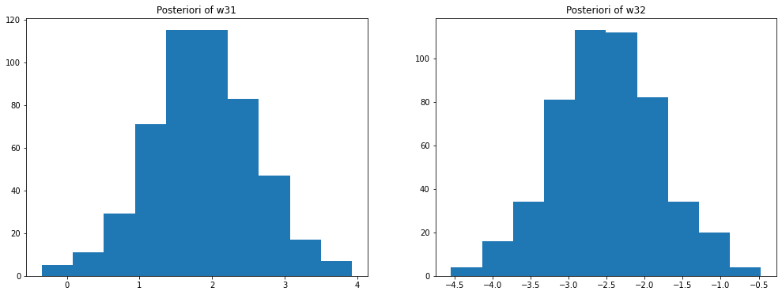

```python
display_posterior_weights(ppc)
```

# Results on the validation set

```python
pm.set_data(new_data = {"input_data": X_valid, "output_data": y_valid}, model = model)

ppc = pm.sample_posterior_predictive(trace, samples = 500, progressbar = True, model = model, var_names = ['w_1', 'w_2', 'out'])

pred = ppc["out"].mean(axis = 0) > 0.5

print("Valid Accuracy: {}".format(accuracy_score(pred, y_valid)))
```

```
Valid Accuracy: 1.0
```

# Comparison with the same architecture in Pytorch

```
Epoch: 0, Train Loss: 0.718, Valid Loss: 0.672, Train Accuracy 0.475, Valid Accuracy: 0.7
Epoch: 50, Train Loss: 0.481, Valid Loss: 0.447, Train Accuracy 0.888, Valid Accuracy: 0.9
Epoch: 100, Train Loss: 0.314, Valid Loss: 0.292, Train Accuracy 0.962, Valid Accuracy: 1.0
Epoch: 150, Train Loss: 0.197, Valid Loss: 0.189, Train Accuracy 0.975, Valid Accuracy: 1.0
Epoch: 200, Train Loss: 0.138, Valid Loss: 0.136, Train Accuracy 0.988, Valid Accuracy: 1.0
Epoch: 250, Train Loss: 0.108, Valid Loss: 0.108, Train Accuracy 0.988, Valid Accuracy: 1.0
Epoch: 300, Train Loss: 0.091, Valid Loss: 0.091, Train Accuracy 0.988, Valid Accuracy: 1.0
Epoch: 350, Train Loss: 0.08, Valid Loss: 0.08, Train Accuracy 0.975, Valid Accuracy: 1.0
Epoch: 400, Train Loss: 0.073, Valid Loss: 0.071, Train Accuracy 0.975, Valid Accuracy: 1.0
Epoch: 450, Train Loss: 0.067, Valid Loss: 0.065, Train Accuracy 0.975, Valid Accuracy: 1.0
```

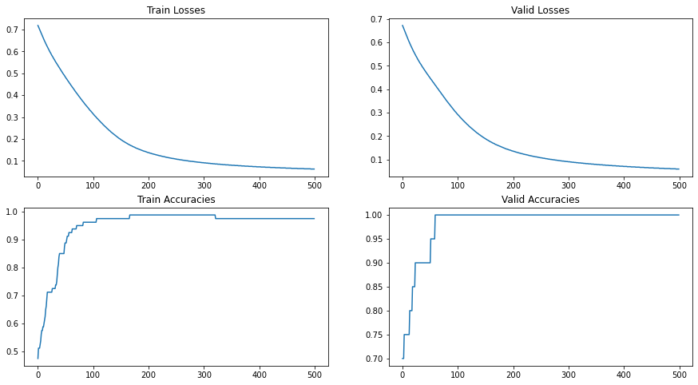

```python
pipeline = TorchPipeline(X_train, y_train, X_valid, y_valid, n_hidden = 2, n_output = 1)
```

# A less separable dataset

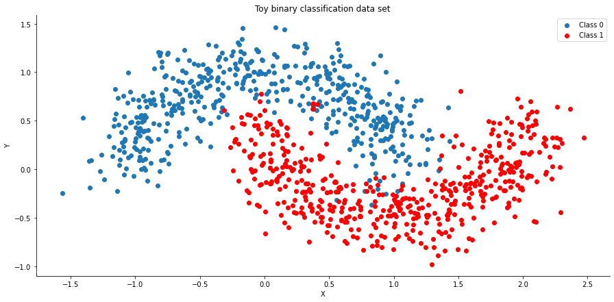

```python
X, Y = make_moons(noise = 0.2, random_state = seed, n_samples = 1000)

display_toy_dataset(X, Y)
```

```python
X_train, X_valid, y_train, y_valid = train_test_split(X, Y, test_size = 0.2, random_state = seed, stratify = Y)

scaler = StandardScaler()
scaler.fit(X_train)

X_train = scaler.fit_transform(X_train)
X_valid = scaler.fit_transform(X_valid)
```

```python
model = BinaryPymcNetwork(X_train, y_train, n_hidden = 2)
```

```python
with model:
    approx = pm.fit(n = 30000)

trace = approx.sample(draws = 5000)
```

```
Finished [100%]: Average Loss = 184.35
```

# Results on the train set

```python
pm.set_data(new_data = {"input_data": X_train, "output_data": y_train}, model = model)

ppc = pm.sample_posterior_predictive(trace, samples = 500, progressbar = True, model = model, var_names = ['w_1', 'w_2', 'out'])

y_pred = ppc["out"].mean(axis = 0) > 0.5

print("Train Accuracy: {}".format(accuracy_score(y_train, y_pred)))
```

```
Train Accuracy: 0.935
```

# Checking the posterior weights

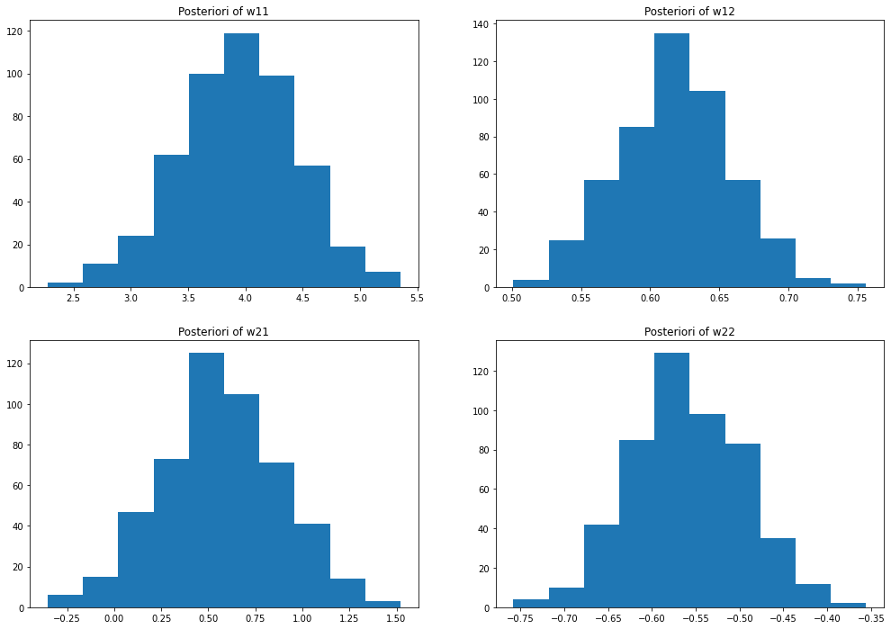

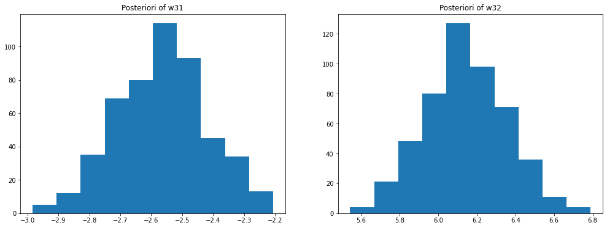

```python
display_posterior_weights(ppc)
```

# Results on the validation set

```python
pm.set_data(new_data = {"input_data": X_valid, "output_data": y_valid}, model = model)

ppc = pm.sample_posterior_predictive(trace, samples = 500, progressbar = True, model = model, var_names = ['w_1', 'w_2', 'out'])

pred = ppc["out"].mean(axis = 0) > 0.5

print("Valid Accuracy: {}".format(accuracy_score(pred, y_valid)))
```

```
Valid Accuracy: 0.915
```

# Comparison with the same architecture in Pytorch

```
Epoch: 0, Train Loss: 0.59, Valid Loss: 0.597, Train Accuracy 0.801, Valid Accuracy: 0.765
Epoch: 50, Train Loss: 0.358, Valid Loss: 0.398, Train Accuracy 0.892, Valid Accuracy: 0.85
Epoch: 100, Train Loss: 0.292, Valid Loss: 0.359, Train Accuracy 0.891, Valid Accuracy: 0.845
Epoch: 150, Train Loss: 0.282, Valid Loss: 0.361, Train Accuracy 0.89, Valid Accuracy: 0.845
Epoch: 200, Train Loss: 0.279, Valid Loss: 0.363, Train Accuracy 0.892, Valid Accuracy: 0.845
Epoch: 250, Train Loss: 0.277, Valid Loss: 0.363, Train Accuracy 0.892, Valid Accuracy: 0.84
Epoch: 300, Train Loss: 0.276, Valid Loss: 0.362, Train Accuracy 0.892, Valid Accuracy: 0.845
Epoch: 350, Train Loss: 0.275, Valid Loss: 0.361, Train Accuracy 0.892, Valid Accuracy: 0.845
Epoch: 400, Train Loss: 0.274, Valid Loss: 0.359, Train Accuracy 0.891, Valid Accuracy: 0.845
Epoch: 450, Train Loss: 0.273, Valid Loss: 0.358, Train Accuracy 0.891, Valid Accuracy: 0.845
```

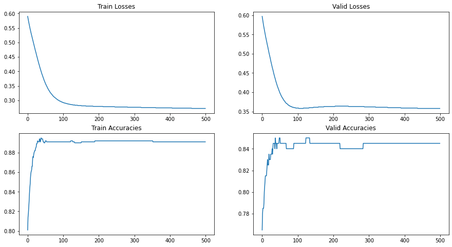

```python
pipeline = TorchPipeline(X_train, y_train, X_valid, y_valid, n_hidden = 2, n_output = 1)
```

# Multiclass classification based on Bayesian Neural Networks

# For this task will use Pyro instead of Pymc

# Define and initialize the same architecture in Pytorch

```python
class PyroNeuralNetwork(nn.Module):
    def __init__(self, input_size, hidden_size, output_size):
        super(PyroNeuralNetwork, self).__init__()
        self.fc1 = nn.Linear(input_size, hidden_size, bias = False)
        self.fc2 = nn.Linear(hidden_size, output_size, bias = False)

    def forward(self, x):
        x = F.tanh(self.fc1(x))
        x = self.fc2(x)

        return x
```

```python
PyroModel = PyroNeuralNetwork(28 * 28, 1024, 10)
```

# Converting regular weights to random variables

- A better way to think about this is attaching each weight between neurons a probability distribution
- And in the end will sample values as outputs from all distributions
- To remeber those are the priors

```python
def model(x_data, y_data):
    log_softmax = nn.LogSoftmax(dim = 1)

    fc1_weight_prior = Normal(loc = torch.zeros_like(PyroModel.fc1.weight), scale = torch.ones_like(PyroModel.fc1.weight))
    fc2_weight_prior = Normal(loc = torch.zeros_like(PyroModel.fc2.weight), scale = torch.ones_like(PyroModel.fc2.weight))

    priors = {'fc1.weight': fc1_weight_prior, 'fc2.weight': fc2_weight_prior}

    lifted_module = pyro.random_module("module", PyroModel, priors)

    lifted_reg_model = lifted_module()

    lhat = log_softmax(lifted_reg_model(x_data))

    pyro.sample("obs", Categorical(logits = lhat), obs = y_data)
```

# The guide function - Hardest thing to understand

- The main idea here it's that the stand alone model function (after we attach random variables) knows only the prior distributions.
- To optimize those priors we need to update them based on training data, generating the posterior distributions that "do well" on the fitted data
- After those posteriors are generated from optimizing the guide function, those will be used to sample models for predictions

```python
def guide(x_data, y_data):
    softplus    = nn.Softplus()

    # First layer weight distribution priors
    fc1_weight_mu    = torch.randn_like(PyroModel.fc1.weight)
    fc1_weight_sigma = torch.randn_like(PyroModel.fc1.weight)

    fc1_weight_mu_param    = pyro.param("fc1_weight_mu", fc1_weight_mu)
    fc1_weight_sigma_param = softplus(pyro.param("fc1_weight_sigma", fc1_weight_sigma))

    fc1_weight_prior = Normal(loc = fc1_weight_mu_param, scale = fc1_weight_sigma_param)

    # Second layer weight distribution priors
    fc2_weight_mu    = torch.randn_like(PyroModel.fc2.weight)
    fc2_weight_sigma = torch.randn_like(PyroModel.fc2.weight)

    fc2_weight_mu_param    = pyro.param("fc2_weight_mu", fc2_weight_mu)
    fc2_weight_sigma_param = softplus(pyro.param("fc2_weight_sigma", fc2_weight_sigma))

    fc2_weight_prior = Normal(loc = fc2_weight_mu_param, scale = fc2_weight_sigma_param).independent(1)

    priors = {'fc1.weight': fc1_weight_prior, 'fc2.weight': fc2_weight_prior}

    lifted_module = pyro.random_module("module", PyroModel, priors)

    return lifted_module()
```

# Standard loading and training iterations

```python
trainset = datasets.MNIST('mnist-data/', train = True,  download = True,  transform = transforms.ToTensor())
validset = datasets.MNIST('mnist-data/', train = False, download = True, transform = transforms.ToTensor())

trainloader = DataLoader(trainset, batch_size = 1024, shuffle=True)
validloader = DataLoader(validset, batch_size = 128,  shuffle=True)
```

```python
optim = Adam({"lr": 0.02})
svi = SVI(model, guide, optim, loss = Trace_ELBO())
```

```python
epochs = 10
for epoch in range(epochs):
    total_loss = 0
    for images, labels in trainloader:
        images = images.view(-1, 28 * 28)
        total_loss += svi.step(images, labels)

    loss = total_loss / len(trainloader)
    print("Epoch: {}, Train Loss: {}".format(epoch + 1, loss))
```

```
Epoch: 1, Train Loss: 530850.7904611361
Epoch: 2, Train Loss: 251639.80416611495
Epoch: 3, Train Loss: 144389.18395789195
Epoch: 4, Train Loss: 96993.70146980933
Epoch: 5, Train Loss: 72061.15353548729
Epoch: 6, Train Loss: 57134.58759269068
Epoch: 7, Train Loss: 47682.105625993114
Epoch: 8, Train Loss: 42500.05931375794
Epoch: 9, Train Loss: 38434.66010659428
Epoch: 10, Train Loss: 35589.968121027545
```

# Predictions on the validation set

```python
def predict(x, num_samples = 100):
    sampled_models = [guide(None, None) for _ in range(num_samples)]
    yhats = [model(x).data for model in sampled_models]
    mean = torch.mean(torch.stack(yhats), 0)
    return torch.argmax(mean, dim = 1)

correct = 0
counter = 0
predictive = Predictive(model, guide = guide, num_samples = 100)
for images, labels in validloader:
    images = images.view(-1, 28 * 28)

    predictions = predict(images)

    #sample = predictive(images, labels)
    #predictions = sample['obs'].float().mean(dim = 0)

    correct += (predictions == labels).sum().item()
    counter += labels.shape[0]

print("Validation Accuracy: {}".format(100 * correct / counter))
```

```
Validation Accuracy: 84.92
```

# Let's check the weight distribution for some parameters

```python
for images, labels in validloader:
    images = images.view(-1, 28 * 28)
    sample = predictive(images, labels)
    break

weights = sample['module$$$fc1.weight'].detach().numpy()
```

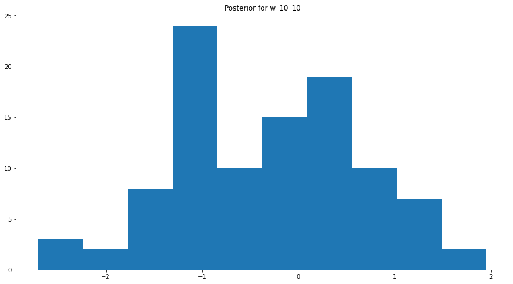

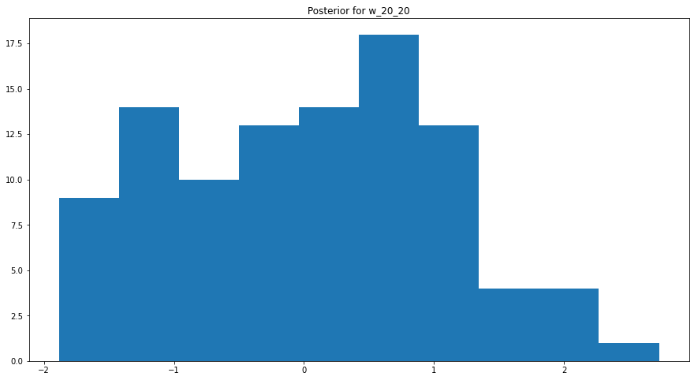

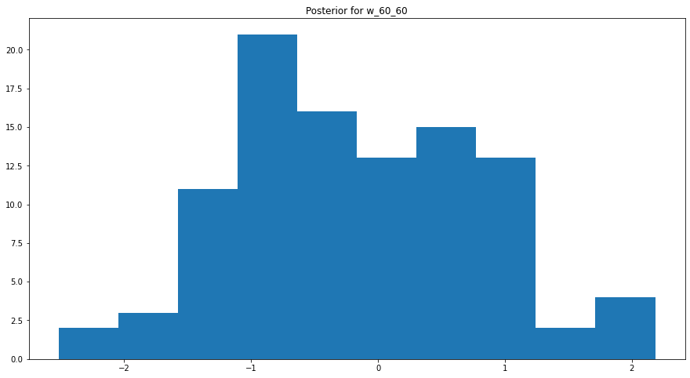

```python
for n in [10, 20, 60]:
    plt.figure(figsize = (15, 8))
    plt.hist(weights[:, n, n])
    plt.title("Posterior for w_{}_{}".format(n, n))
    plt.show()
```

- Taking into consideration the fact that MNIST it's the "Hello World" in machine learnig, I decided to not train a baseline model in Pytorch
- It's a trivial task and will just considerate the accuracy to be over 90% (with or without convolutions)

# Things that did not work

- Pymc3 Muliclass classification -> Example Below

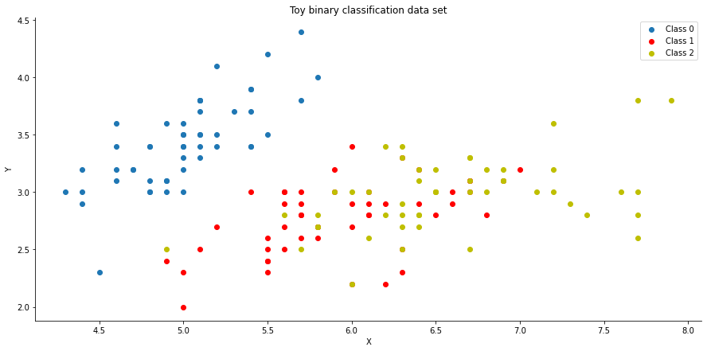

```python
data = load_iris()
X = data.data
Y = data.target

display_toy_dataset(X, Y, necessary = True)
```

```python
X_train, X_valid, y_train, y_valid = train_test_split(X, Y, test_size = 0.2, random_state = seed, stratify = Y)

scaler = StandardScaler()
scaler.fit(X_train)

X_train = scaler.fit_transform(X_train)
X_valid = scaler.fit_transform(X_valid)
```

# Keeping it simple, the same architecture

- To keep things simple will try to adapt the binary network configuration for multi class
- And also changing the number of neurons in the hidden layer and the number of layers

# Machine Learning Hell: Layer One -> Module Dependencies

- The biggest problem during this project was chosing the right versions between theano and pymc3
- From my research there is some compatibilty issue between modules that might not be so easy to fix

# A simple solution

- If you need to rerun this notebook for the bayesian multiclass network I recommend you to create a new Anaconda Env with just Python and Jupyter
- And just run the first cell for installation without Theano
- After this, you can install Theano and things will work perfectly
- But after the kernel is restarted pymc3 night not work
- For a better solution more research is necessary

```python
! conda install -c conda-forge -y theano==1.0.5
```

[output not shown]

```python
import theano.tensor as T
```

# Bad results from Pymc architecture

```python
def CategoricalPymcNetwork(input_data, output_data, n_hidden, n_class):
    input_size = input_data.shape[1]
    total_size = output_data.shape[0]


    init_1 = np.random.randn(input_size, n_hidden).astype(float)
    init_2 = np.random.randn(n_hidden, n_hidden).astype(float)
    init_3 = np.random.randn(n_hidden, n_class).astype(float)


    with pm.Model() as nn:
        input_data  = pm.Data('input_data',  input_data)
        output_data = pm.Data('output_data', output_data)

        weights_1 = pm.Normal("w_1", mu = 0, sigma = 1, shape = (input_size, n_hidden), testval = init_1)
        weights_2 = pm.Normal("w_2", mu = 0, sigma = 1, shape = (n_hidden, n_hidden), testval = init_2)
        weights_3 = pm.Normal("w_3", mu = 0, sigma = 1, shape = (n_hidden, n_class), testval = init_3)

        activation_1 = pm.math.tanh(pm.math.dot(input_data, weights_1))
        activation_2 = pm.math.tanh(pm.math.dot(activation_1, weights_2))
        activation_3 = T.nnet.softmax(pm.math.dot(activation_2, weights_3))

        output = pm.Categorical("out", p = activation_3, observed = output_data, total_size = total_size)

    return nn
```

```python
model = CategoricalPymcNetwork(X_train, y_train, n_hidden = 5, n_class = 3)
```

```python
with model:
    approx = pm.fit(n = 30000)

trace = approx.sample(draws = 5000)
```

```
Finished [100%]: Average Loss = 15,960
```

# Results on the train set

```python
ppc = pm.sample_posterior_predictive(trace, samples = 500, progressbar = True, model = model, var_names = ['w_1', 'w_2', 'out'])

y_pred = ppc["out"][-1]

print("Train Accuracy: {}".format(accuracy_score(y_train, y_pred)))
```

```
Train Accuracy: 0.39166666666666666
```

# Results on the validation set

```python
pm.set_data(new_data = {"input_data": X_valid, "output_data": y_valid}, model = model)

ppc = pm.sample_posterior_predictive(trace, samples = 500, progressbar = True, model = model, var_names = ['w_1', 'w_2', 'out'])

pred = ppc["out"][-1]

print("Valid Accuracy: {}".format(accuracy_score(pred, y_valid)))
```

```
Valid Accuracy: 0.4
```

# It's just random change, most likely it's something wrong

# Comparison with the same architecture in Pytorch

```
Epoch: 0, Train Loss: 1.035, Valid Loss: 1.003, Train Accuracy 0.333, Valid Accuracy: 0.333
Epoch: 50, Train Loss: 0.416, Valid Loss: 0.409, Train Accuracy 0.783, Valid Accuracy: 0.8
Epoch: 100, Train Loss: 0.313, Valid Loss: 0.379, Train Accuracy 0.833, Valid Accuracy: 0.867
Epoch: 150, Train Loss: 0.256, Valid Loss: 0.397, Train Accuracy 0.883, Valid Accuracy: 0.867
Epoch: 200, Train Loss: 0.216, Valid Loss: 0.375, Train Accuracy 0.925, Valid Accuracy: 0.867
Epoch: 250, Train Loss: 0.175, Valid Loss: 0.337, Train Accuracy 0.933, Valid Accuracy: 0.867
Epoch: 300, Train Loss: 0.144, Valid Loss: 0.302, Train Accuracy 0.95, Valid Accuracy: 0.867
Epoch: 350, Train Loss: 0.121, Valid Loss: 0.275, Train Accuracy 0.967, Valid Accuracy: 0.867
Epoch: 400, Train Loss: 0.106, Valid Loss: 0.252, Train Accuracy 0.975, Valid Accuracy: 0.9
Epoch: 450, Train Loss: 0.094, Valid Loss: 0.233, Train Accuracy 0.975, Valid Accuracy: 0.933
```

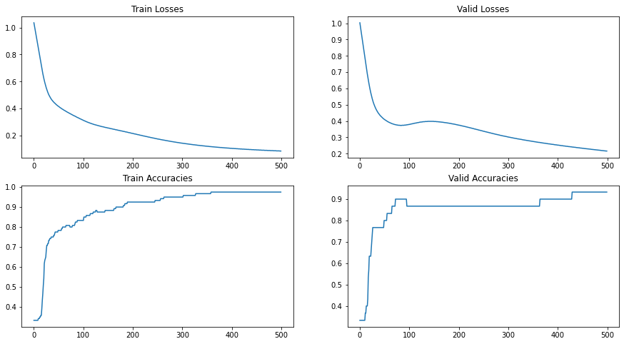

```python
pipeline = TorchPipeline(X_train, y_train, X_valid, y_valid, n_hidden = 5, n_output = 3, typs = 'multiclass')
```